# MOSAIC: Quick Start Tutorial

Chang Lu, Yuval Kluger, and Rong Ma

2025-11-21

## 1 Introduction

MOSAIC is a spectral framework for integrative phenotypic characterization using population-level single-cell multi-omics. This tutorial demonstrates how to:

1. Run MOSAIC on paired RNA+ADT data.
2. Perform Differential Connectivity (DC) analysis.
3. Visualize rewired features and patient subgroups.

## 2 1.Setup and Data Loading

```r
library(Seurat)
library(SeuratDisk)
library(RSpectra)
library(ggplot2)
library(doParallel)
library(foreach)
library(dplyr)
library(vegan)
library(MASS)
library(ReactomePA)
library(clusterProfiler)
library(org.Hs.eg.db)
library(lsa)
library(pheatmap)
library(cluster)
source("/banach2/chang/cleaned_rong_project/script/MOSAIC_function.R")
```

We utilize a subset of a CITE-seq dataset (human T-cells, vaccination cohort). To speed up this tutorial, we have pre-filtered the dataset to CD4+ Naive T-cells and retained informative features.

```r
pbmc <- LoadH5Seurat("/banach2/chang/cleaned_rong_project/dataset/multi.h5seurat")

# subset to certain cell type and timepoint
seurat_subset <- subset(pbmc, idents = "CD4 Naive")
seurat_subset <- seurat_subset[,which(seurat_subset$time %in% c(0,7))]

# Feature selection
counts <- GetAssayData(seurat_subset, assay = "SCT", slot = "counts")
sample_ids <- unique(as.character(seurat_subset$orig.ident))
list_of_expressed_genes <- lapply(sample_ids, function(id) {
  cells_in_sample <- which(seurat_subset$orig.ident == id)
  sample_counts <- counts[, cells_in_sample, drop = FALSE]
  expressed_genes <- rownames(sample_counts)[rowSums(sample_counts) > 3]
  return(expressed_genes)
})
genes_to_keep <- Reduce(intersect, list_of_expressed_genes)

counts <- GetAssayData(seurat_subset, assay = "ADT", slot = "counts")
sample_ids <- unique(as.character(seurat_subset$orig.ident))
list_of_expressed_genes <- lapply(sample_ids, function(id) {
  cells_in_sample <- which(seurat_subset$orig.ident == id)
  sample_counts <- counts[, cells_in_sample, drop = FALSE]
  expressed_genes <- rownames(sample_counts)[rowSums(sample_counts) > 3]
  return(expressed_genes)
})
protein_to_keep <- Reduce(intersect, list_of_expressed_genes)

seurat_subset[["SCT"]] <- subset(seurat_subset[["SCT"]], features = genes_to_keep)
seurat_subset[["ADT"]] <- subset(seurat_subset[["ADT"]], features = protein_to_keep)

seurat_subset$cluster_id <- "CD4 Naive"
seurat_subset$sample_id <- seurat_subset$orig.ident
seurat_subset$group_id <- seurat_subset$time

feature_names <- c(paste0("RNA_",rownames(seurat_subset@assays$SCT$counts)),paste0("ADT_",rownames(seurat_subset@assays$ADT$counts)))
feature_names_no_preflix <- c(rownames(seurat_subset@assays$SCT$counts),rownames(seurat_subset@assays$ADT$counts))

seurat_rna <- seurat_subset
seurat_rna[["ADT"]] <- NULL
seurat_adt <- seurat_subset
DefaultAssay(seurat_adt) <- "ADT"
seurat_adt[["SCT"]] <- NULL

seurat_rna <- NormalizeData(seurat_rna)
seurat_adt <- NormalizeData(seurat_adt, assay = "ADT", normalization.method = "CLR")
```

## 3 Run MOSAIC

We construct the sample-specific coupling matrices and perform spectral integration. - sample_meta: Column name for Sample IDs. - condition_meta: Column name for Condition/Group (e.g., Day 0 vs Day 7).

```r
MOSAIC_result <- run_MOSAIC_two_modality(seurat_rna,seurat_adt,sample_meta="sample_id",condition_meta="time")
```

```
## [1] "Processing sample 1"
## [1] "Finish calculating coupling matrix"
## [1] "Finish eigendecomposition"
## [1] "Processing sample 2"
## [1] "Finish calculating coupling matrix"
## [1] "Finish eigendecomposition"
## [1] "Processing sample 3"
## [1] "Finish calculating coupling matrix"
## [1] "Finish eigendecomposition"
## [1] "Processing sample 4"
## [1] "Finish calculating coupling matrix"
## [1] "Finish eigendecomposition"
## [1] "Processing sample 5"
## [1] "Finish calculating coupling matrix"
## [1] "Finish eigendecomposition"
```

[output cut: 34 more lines]

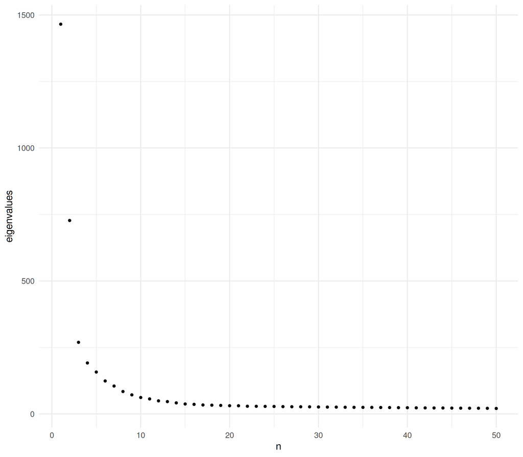

```r
plot_eigen(MOSAIC_result$eigenvalues)
```

## 4 Differential Connectivity (DC) Analysis

To identify features that rewire their network connections between conditions (independent of abundance), we calculate an empirical p-value using permutation testing.

```r
set.seed(123)
shuffled_indices <- sample(nrow(seurat_rna@meta.data))
seurat_rna@meta.data[,"shuffled_sample_id"] <- seurat_rna@meta.data[,"sample_id"][shuffled_indices]
seurat_rna@meta.data[,"shuffled_condition_id"] <- seurat_rna@meta.data[,"time"][shuffled_indices]

seurat_adt@meta.data[,"shuffled_sample_id"] <- seurat_adt@meta.data[,"sample_id"][shuffled_indices]
seurat_adt@meta.data[,"shuffled_condition_id"] <- seurat_adt@meta.data[,"time"][shuffled_indices]

MOSAIC_shuffle_result <- run_MOSAIC_two_modality(seurat_rna,seurat_adt,sample_meta="shuffled_sample_id",condition_meta="shuffled_condition_id")
```

```
## [1] "Processing sample 1"
## [1] "Finish calculating coupling matrix"
## [1] "Finish eigendecomposition"
## [1] "Processing sample 2"
## [1] "Finish calculating coupling matrix"
## [1] "Finish eigendecomposition"
## [1] "Processing sample 3"
## [1] "Finish calculating coupling matrix"
## [1] "Finish eigendecomposition"
## [1] "Processing sample 4"
## [1] "Finish calculating coupling matrix"
## [1] "Finish eigendecomposition"
## [1] "Processing sample 5"
## [1] "Finish calculating coupling matrix"
## [1] "Finish eigendecomposition"
```

[output cut: 34 more lines]

Calculate PERMANOVA F-statistics for both true and shuffled situation

```r
n_sample <- length(MOSAIC_result$projected_combed_list)
peranova_result <- cal_peranova_per_feature_parallel_no_zero(MOSAIC_result$projected_combed_list,n_sample,groups = MOSAIC_result$annotation[names(MOSAIC_result$eigen_output_cosine_list),"Condition"],dist_method ="eu",num_permutation=999)

shuffle_peranova_result <- cal_peranova_per_feature_parallel_no_zero(MOSAIC_shuffle_result$projected_combed_list,n_sample,groups = MOSAIC_shuffle_result$annotation[names(MOSAIC_shuffle_result$eigen_output_cosine_list),"Condition"],dist_method = "eu",num_permutation=999)
```

```r
F_list <- unlist(peranova_result$F_stats_list)
shuffle_F_stats <- unlist(shuffle_peranova_result$F_stats)
pvalue_F <- unlist(lapply(F_list, function(x) calculate_empirical_pvalue(x,shuffle_F_stats)))
r2_list <- unlist(peranova_result$r2_list)

differential_idx <- which(pvalue_F < 0.05)
feature_names_filtered <- feature_names[differential_idx]
feature_names_filtered_no_prelix <- feature_names_no_preflix[differential_idx]

DC_table <- data.frame(
  Feature = feature_names[differential_idx],
  Adj_Pvalue = pvalue_F[differential_idx],
  F_Statistic = F_list[differential_idx]
) %>%
  arrange(Adj_Pvalue)

DC_table$rank <- 1:dim(DC_table)[1]
print(head(DC_table))
```

```
##      Feature Adj_Pvalue F_Statistic rank
## 1 RNA_DEPDC5 0.00010202    18.22877    1
## 2   RNA_BAP1 0.00030606    17.58016    2
## 3  RNA_ZNF92 0.00030606    17.05720    3
## 4  RNA_INTS4 0.00030606    16.57960    4
## 5 RNA_ZNF275 0.00040808    14.65680    5
## 6  RNA_DHX34 0.00051010    13.93133    6
```

## 5 Visualization

### 5.1 Pathway Enrichment of DC Features

```r
feature_list <- feature_names_filtered_no_prelix
#background_genes <- feature_names_no_preflix

protein_to_gene <- c(
  "CD135" = "FLT3",      # CD135 is FLT3 receptor
  "CD307d" = "FCRL4"     # CD307d is FCRL4
)

feature_list_converted <- feature_list
for(protein in names(protein_to_gene)) {
  feature_list_converted[feature_list_converted == protein] <- protein_to_gene[protein]
}

entrez_ids <- bitr(feature_list_converted,
                   fromType = "SYMBOL",
                   toType = "ENTREZID",
                   OrgDb = org.Hs.eg.db)
```

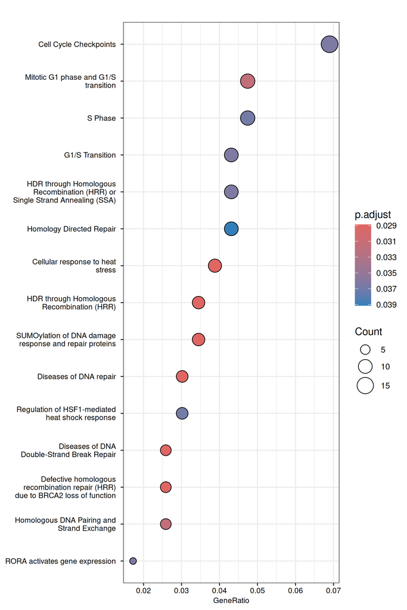

```r
reactome_results <- enrichPathway(
  gene = entrez_ids$ENTREZID,
  pvalueCutoff = 0.05,
  readable = TRUE
)

# Plot results
p <- dotplot(reactome_results, showCategory = 15, font.size = 8) +
  theme(axis.text.y = element_text(size = 8, margin = margin(r = 5)))
p
```

### 5.2 Visualizing a Specific Rewired Feature

```r
r2_list_filtered <- r2_list[differential_idx]
pvalue_F_filtered <- pvalue_F[differential_idx]
names(pvalue_F_filtered) <- feature_names_filtered
indices_desc <- order(r2_list_filtered, decreasing = TRUE)
feature_name_ordered <- feature_names_filtered[indices_desc]

chosen_idx <- 93

idx_single_feature <- differential_idx[indices_desc[chosen_idx]]
similarity_matrix <- peranova_result$similarity_matrix_list[[idx_single_feature]]
condition_single_feature <- peranova_result$group_list[[idx_single_feature]]
annotation_single_feature <- data.frame(Condition = condition_single_feature)
rownames(annotation_single_feature) <- rownames(similarity_matrix)
chosen_feature_name <- feature_names[idx_single_feature]
print(chosen_feature_name)
```

```
## [1] "RNA_STAT5B"
```

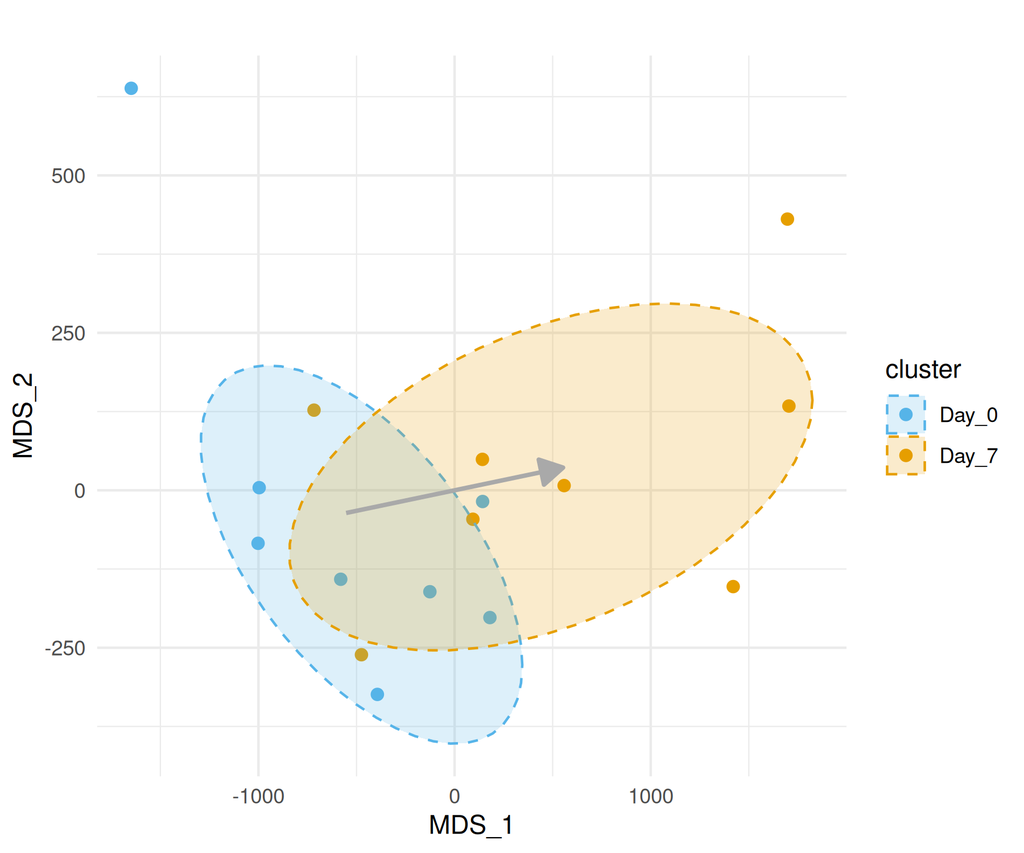

```r
p <- plot_mds_cluster_arrow(
  similarity_matrix,
  "",
  paste0("Day_", condition_single_feature),
  size = 2,
  dis = FALSE,
  add_ellipse = TRUE,
  ellipse_level=0.68,
  custom_colors = c("Day_0" = "#56B4E9", "Day_7" = "#E69F00"),
  add_arrow_from_to = c("Day_0", "Day_7") # <-- Add this line
)

print(p)
```

### 5.3 Patient Subgroup Detection

We compute the sample similarity matrix based on the identified DC features.

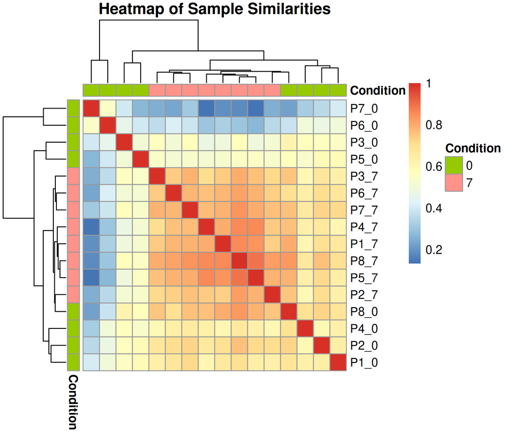

```r
n_sample <- length(MOSAIC_result$projected_combed_list)
similarity_matrix <- matrix(0, nrow = n_sample, ncol = n_sample)
for (i in 1:n_sample){
  for (j in 1:n_sample){
    x <- MOSAIC_result$projected_combed_list[[i]][differential_idx,]
    y <- MOSAIC_result$projected_combed_list[[j]][differential_idx,]
    #similarity_matrix[i,j] <- calculate_matrix_residual(x,y)
    similarity_matrix[i,j] <- cosine(as.vector(x),as.vector(y))
  }
}

rownames(similarity_matrix) <- names(MOSAIC_result$projected_combed_list)
colnames(similarity_matrix) <- names(MOSAIC_result$projected_combed_list)

p <- pheatmap(
  #  similarity_matrix[selected_sample_id,selected_sample_id],
  similarity_matrix,
  annotation_row = MOSAIC_result$annotation,
  annotation_col = MOSAIC_result$annotation,
  main = paste0("Heatmap of Sample Similarities"),
  cluster_rows = TRUE,  # Enable clustering for rows
  cluster_cols = TRUE,  # Enable clustering for columns
  show_rownames = TRUE,
  show_colnames = FALSE
)
```

```r
condition <- MOSAIC_result$annotation$Condition
condition_numeric <- as.integer(as.factor(condition))
silhouette_scores <- silhouette(condition_numeric, 1-similarity_matrix)
average_silhouette_score <- mean(silhouette_scores[, "sil_width"])
print(average_silhouette_score)
```

```
## [1] 0.2110472
```

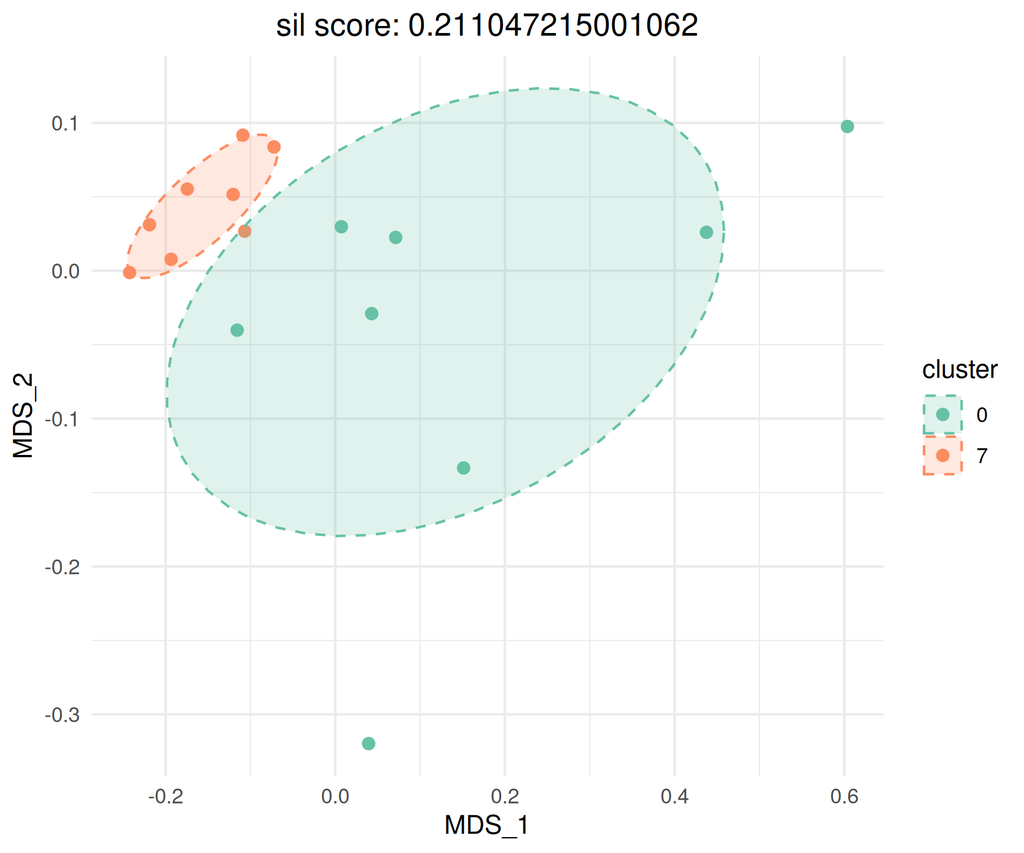

```r
p <- plot_mds_cluster_arrow(similarity_matrix,"",condition,size=2,dis = FALSE)+ggtitle(paste0("sil score: ",average_silhouette_score))
p
```